# Assignment 1: Adult Income Analysis

Nusrat Nasir Nimnee

2025-09-05

# Introduction

This report analyzes the ‘Adult Income’ dataset to explore the factors that influence whether an individual earns over $50K a year.

# Data Loading and Preparation

This dataset collected from kaggle dataset. Dataset Source: https://www.kaggle.com/datasets/serpilturanyksel/adult-income

```r
# Clear the global environment
rm(list = ls())

# Load required packages
# install.packages("gtsummary")
# install.packages("tidyverse")
library(tidyverse)
library(gtsummary)
```

```r
# Load the dataset
# The dataset is expected to be in the same directory as this Rmd file.
Income_df <- read.csv("adult_income_data.csv")
```

# Exploratory Data Analysis

## Basic Summary

Here is a basic summary of the dataset.

```r
str(Income_df)
```

```
## 'data.frame':    48842 obs. of  15 variables:
##  $ age           : int  25 38 28 44 18 34 29 63 24 55 ...
##  $ workclass     : chr  "Private" "Private" "Local-gov" "Private" ...
##  $ fnlwgt        : int  226802 89814 336951 160323 103497 198693 227026 104626 369667 104996 ...
##  $ education     : chr  "11th" "HS-grad" "Assoc-acdm" "Some-college" ...
##  $ education.num : int  7 9 12 10 10 6 9 15 10 4 ...
##  $ marital.status: chr  "Never-married" "Married-civ-spouse" "Married-civ-spouse" "Married-civ-spouse" ...
##  $ occupation    : chr  "Machine-op-inspct" "Farming-fishing" "Protective-serv" "Machine-op-inspct" ...
##  $ relationship  : chr  "Own-child" "Husband" "Husband" "Husband" ...
##  $ race          : chr  "Black" "White" "White" "Black" ...
##  $ gender        : chr  "Male" "Male" "Male" "Male" ...
##  $ capital.gain  : int  0 0 0 7688 0 0 0 3103 0 0 ...
##  $ capital.loss  : int  0 0 0 0 0 0 0 0 0 0 ...
##  $ hours.per.week: int  40 50 40 40 30 30 40 32 40 10 ...
##  $ native.country: chr  "United-States" "United-States" "United-States" "United-States" ...
##  $ salary        : chr  "<=50K" "<=50K" ">50K" ">50K" ...
```

```r
summary(Income_df)
```

```
##       age         workclass             fnlwgt         education
##  Min.   :17.00   Length:48842       Min.   :  12285   Length:48842
##  1st Qu.:28.00   Class :character   1st Qu.: 117551   Class :character
##  Median :37.00   Mode  :character   Median : 178145   Mode  :character
##  Mean   :38.64                      Mean   : 189664
##  3rd Qu.:48.00                      3rd Qu.: 237642
##  Max.   :90.00                      Max.   :1490400
##  education.num   marital.status      occupation        relationship
##  Min.   : 1.00   Length:48842       Length:48842       Length:48842
##  1st Qu.: 9.00   Class :character   Class :character   Class :character
##  Median :10.00   Mode  :character   Mode  :character   Mode  :character
##  Mean   :10.08
##  3rd Qu.:12.00
##  Max.   :16.00
##      race              gender           capital.gain    capital.loss
##  Length:48842       Length:48842       Min.   :    0   Min.   :   0.0
##  Class :character   Class :character   1st Qu.:    0   1st Qu.:   0.0
##  Mode  :character   Mode  :character   Median :    0   Median :   0.0
##                                        Mean   : 1079   Mean   :  87.5
##                                        3rd Qu.:    0   3rd Qu.:   0.0
##                                        Max.   :99999   Max.   :4356.0
##  hours.per.week  native.country        salary
##  Min.   : 1.00   Length:48842       Length:48842
##  1st Qu.:40.00   Class :character   Class :character
##  Median :40.00   Mode  :character   Mode  :character
##  Mean   :40.42
##  3rd Qu.:45.00
##  Max.   :99.00
```

## Detailed Summary Table

A more detailed and formatted summary using the `gtsummary` package, comparing income levels.

```r
Income_df %>%
  tbl_summary(by = salary) %>%
  add_p() %>%
  add_overall() %>%
  bold_labels()
```

| **Characteristic** | **Overall** N = 48,842<sup>1</sup> | **<=50K** N = 37,155<sup>1</sup> | **>50K** N = 11,687<sup>1</sup> | **p-value**<sup>2</sup> |
| --- | --- | --- | --- | --- |
| age | 37 (28, 48) | 34 (25, 46) | 43 (36, 51) | <0.001 |
| workclass |  |  |  |  |
| ? | 2,799 (5.7%) | 2,534 (6.8%) | 265 (2.3%) |  |
| Federal-gov | 1,432 (2.9%) | 871 (2.3%) | 561 (4.8%) |  |
| Local-gov | 3,136 (6.4%) | 2,209 (5.9%) | 927 (7.9%) |  |
| Never-worked | 10 (<0.1%) | 10 (<0.1%) | 0 (0%) |  |
| Private | 33,906 (69%) | 26,519 (71%) | 7,387 (63%) |  |
| Self-emp-inc | 1,695 (3.5%) | 757 (2.0%) | 938 (8.0%) |  |
| Self-emp-not-inc | 3,862 (7.9%) | 2,785 (7.5%) | 1,077 (9.2%) |  |
| State-gov | 1,981 (4.1%) | 1,451 (3.9%) | 530 (4.5%) |  |
| Without-pay | 21 (<0.1%) | 19 (<0.1%) | 2 (<0.1%) |  |
| fnlwgt | 178,145 (117,549, 237,646) | 178,811 (117,210, 238,917) | 176,729 (118,941, 233,511) | 0.2 |
| education |  |  |  | <0.001 |
| 10th | 1,389 (2.8%) | 1,302 (3.5%) | 87 (0.7%) |  |
| 11th | 1,812 (3.7%) | 1,720 (4.6%) | 92 (0.8%) |  |
| 12th | 657 (1.3%) | 609 (1.6%) | 48 (0.4%) |  |
| 1st-4th | 247 (0.5%) | 239 (0.6%) | 8 (<0.1%) |  |
| 5th-6th | 509 (1.0%) | 482 (1.3%) | 27 (0.2%) |  |
| 7th-8th | 955 (2.0%) | 893 (2.4%) | 62 (0.5%) |  |
| 9th | 756 (1.5%) | 715 (1.9%) | 41 (0.4%) |  |
| Assoc-acdm | 1,601 (3.3%) | 1,188 (3.2%) | 413 (3.5%) |  |
| Assoc-voc | 2,061 (4.2%) | 1,539 (4.1%) | 522 (4.5%) |  |
| Bachelors | 8,025 (16%) | 4,712 (13%) | 3,313 (28%) |  |
| Doctorate | 594 (1.2%) | 163 (0.4%) | 431 (3.7%) |  |
| HS-grad | 15,784 (32%) | 13,281 (36%) | 2,503 (21%) |  |
| Masters | 2,657 (5.4%) | 1,198 (3.2%) | 1,459 (12%) |  |
| Preschool | 83 (0.2%) | 82 (0.2%) | 1 (<0.1%) |  |
| Prof-school | 834 (1.7%) | 217 (0.6%) | 617 (5.3%) |  |
| Some-college | 10,878 (22%) | 8,815 (24%) | 2,063 (18%) |  |
| education.num | 10 (9, 12) | 9 (9, 10) | 12 (10, 13) | <0.001 |

[output cut: 86 more lines]

<sup>1</sup> Median (Q1, Q3); n (%)  
<sup>2</sup> Wilcoxon rank sum test; Pearson’s Chi-squared test

# Data Transformation

Before visualization, let’s transform at least one variable as required. We’ll create a log transformation of hours per week to normalize the distribution.

```r
# Transform hours.per.week using log transformation
# Adding 1 to avoid log(0) issues
Income_df$log_hours_per_week <- log(Income_df$hours.per.week + 1)

# Show summary of original and transformed variable
cat("Original hours.per.week summary:\n")
```

```
## Original hours.per.week summary:
```

```r
summary(Income_df$hours.per.week)
```

```
##    Min. 1st Qu.  Median    Mean 3rd Qu.    Max.
##    1.00   40.00   40.00   40.42   45.00   99.00
```

```r
cat("Log-transformed hours.per.week summary:\n")
```

```
## Log-transformed hours.per.week summary:
```

```r
summary(Income_df$log_hours_per_week)
```

```
##    Min. 1st Qu.  Median    Mean 3rd Qu.    Max.
##  0.6931  3.7136  3.7136  3.6645  3.8286  4.6052
```

# Data Visualization

Visualizing the data helps in understanding the relationships between different variables and the income level.

## Quantitative Variable Plot

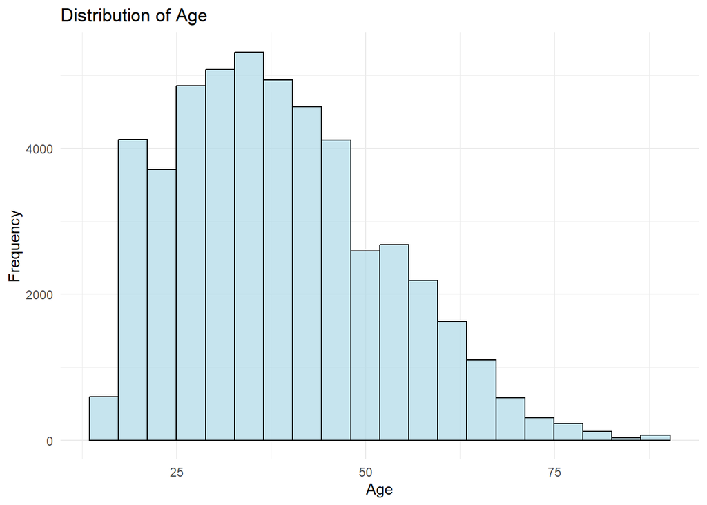

```r
# Plot of a quantitative variable: Age distribution
ggplot(Income_df, aes(x = age)) +
  geom_histogram(bins = 20, fill = "lightblue", color = "black", alpha = 0.7) +
  labs(title = "Distribution of Age",
       x = "Age",
       y = "Frequency") +
  theme_minimal()
```

## Scatterplot

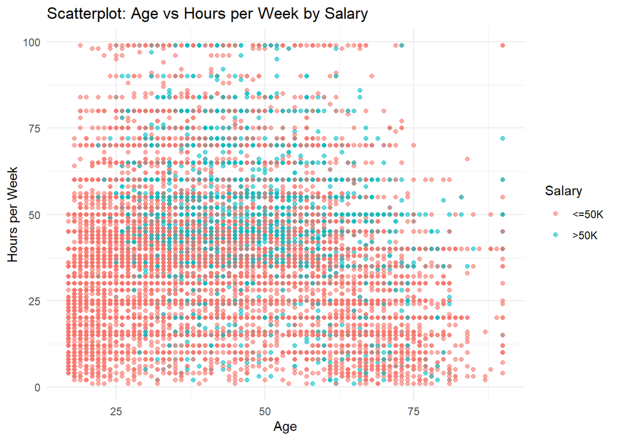

```r
# Scatterplot: Age vs Hours per week
ggplot(Income_df, aes(x = age, y = hours.per.week, color = salary)) +
  geom_point(alpha = 0.6) +
  labs(title = "Scatterplot: Age vs Hours per Week by Salary",
       x = "Age",
       y = "Hours per Week",
       color = "Salary") +
  theme_minimal()
```

## Additional Visualizations

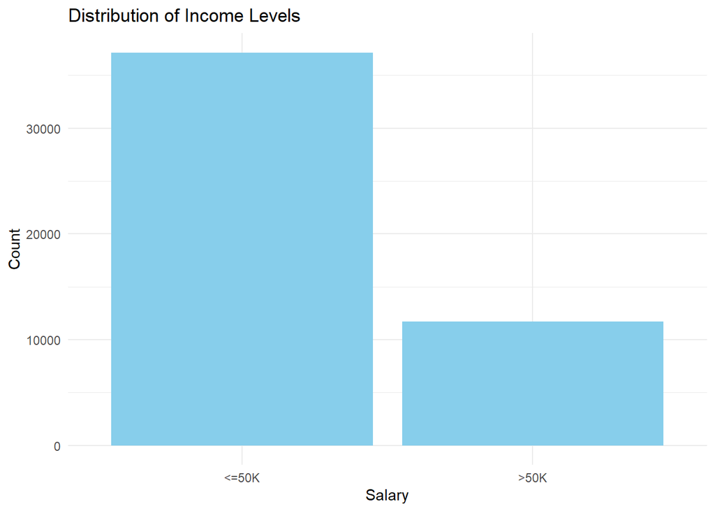

```r
# Distribution of Income
ggplot(Income_df, aes(x = salary)) +
  geom_bar(fill = "skyblue") +
  labs(title = "Distribution of Income Levels", x = "Salary", y = "Count") +
  theme_minimal()
```

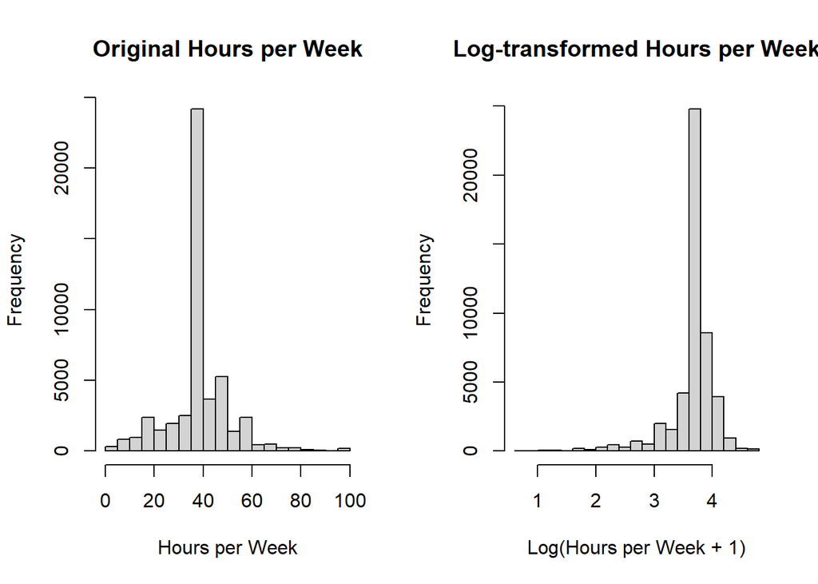

```r
# Comparison of original vs transformed variable
par(mfrow = c(1, 2))
hist(Income_df$hours.per.week, main = "Original Hours per Week", xlab = "Hours per Week")
hist(Income_df$log_hours_per_week, main = "Log-transformed Hours per Week", xlab = "Log(Hours per Week + 1)")
```

# Conclusion

This report presents an exploratory data analysis of the adult income dataset. After loading data, several key insights were gathered through summary statistics and visualizations.

These initial findings provide a solid foundation for understanding the dataset’s characteristics and can inform future predictive modeling tasks.